# HM7_Hanson

1. Read in auto.csv file into a dataframe, and call it Auto. This is what you did at the end of HM 6.

```python
%matplotlib inline
import numpy as np
import matplotlib.pyplot as plt
import pandas as pd
```

```python
auto = pd.read_csv(r'C:\Users\brook\Documents\Summer Class\Auto.csv')
```

1. Replace any missing values with the median value of the variable (feature). Use the pandas fucntion .fillna()

```python
auto = auto.fillna(auto.median(), inplace=False)
auto.head()
```

[output not shown]

1. You will need to fix the “Weight” collumn with this code: Auto['Weight (lbs)'] = Auto['Weight (lbs)'].str.replace(',', '').astype("float"). Run that, but explain why you needed to do this and what it did. Do this in a markup box below your code.

```python
auto.head()
```

|  | Name | Drive Type | Mileage (mpg) | Fuel Type | Capacity (gal) | Length (inches) | Wheel Base (inches) | Width (inches) | Turning Circle (feet) | Weight (lbs) | Door Top (inches) | Luggage (cu. ft.) | Front Shoulder (inches) | Front Leg Room (inches) | Front Head Room (inches) | Rear Shoulder (inches) | Rear Leg Room (inches) | Rear Head Room (inches) |
| --- | --- | --- | --- | --- | --- | --- | --- | --- | --- | --- | --- | --- | --- | --- | --- | --- | --- | --- |
| 0 | Acura TL | Front | 22 | Premium | 17.1 | 193 | 108 | 70 | 40 | 3,460 | 50.0 | 14.0 | 56.0 | 40.5 | 2.5 | 55.0 | 27.0 | 2.0 |
| 1 | Infiniti I30 | Front | 22 | Premium | 18.5 | 194 | 108 | 70 | 40 | 3,410 | 51.0 | 14.0 | 56.0 | 40.0 | 3.0 | 56.0 | 29.0 | 2.0 |
| 2 | Land Rover Discovery | Front | 14 | Premium | 24.1 | 185 | 100 | 74 | 47 | 4,735 | 65.0 | 46.5 | 58.0 | 39.0 | 5.5 | 57.0 | 27.0 | 5.0 |
| 3 | Lexus ES300 | Front | 22 | Premium | 18.5 | 190 | 105 | 71 | 40 | 3,390 | 50.0 | 13.0 | 55.0 | 41.0 | 2.0 | 53.5 | 27.5 | 1.5 |
| 4 | Mercedes-Benz M-Class | Front | 19 | Premium | 19.0 | 181 | 111 | 72 | 35 | 4,405 | 64.5 | 45.5 | 58.5 | 41.0 | 3.5 | 57.5 | 29.5 | 4.5 |

We can see here (above^) that weight includes commas and has no decimals behind it which coresponds with the dtype=object (below). We need to change weight from and object to a float.

```python
auto.dtypes
```

```
Name                         object
Drive Type                   object
Mileage (mpg)                 int64
Fuel Type                    object
Capacity (gal)              float64
Length (inches)               int64
Wheel Base (inches)           int64
Width (inches)                int64
Turning Circle (feet)         int64
Weight (lbs)                 object
Door Top (inches)           float64
Luggage (cu. ft.)           float64
Front Shoulder (inches)     float64
Front Leg Room (inches)     float64
Front Head Room (inches)    float64
Rear Shoulder (inches)      float64
Rear Leg Room (inches)      float64
Rear Head Room (inches)     float64
dtype: object
```

```python
auto['Weight (lbs)'] = auto['Weight (lbs)'].str.replace(',', '').astype("float")
```

```python
auto.head()
```

|  | Name | Drive Type | Mileage (mpg) | Fuel Type | Capacity (gal) | Length (inches) | Wheel Base (inches) | Width (inches) | Turning Circle (feet) | Weight (lbs) | Door Top (inches) | Luggage (cu. ft.) | Front Shoulder (inches) | Front Leg Room (inches) | Front Head Room (inches) | Rear Shoulder (inches) | Rear Leg Room (inches) | Rear Head Room (inches) |
| --- | --- | --- | --- | --- | --- | --- | --- | --- | --- | --- | --- | --- | --- | --- | --- | --- | --- | --- |
| 0 | Acura TL | Front | 22 | Premium | 17.1 | 193 | 108 | 70 | 40 | 3460.0 | 50.0 | 14.0 | 56.0 | 40.5 | 2.5 | 55.0 | 27.0 | 2.0 |
| 1 | Infiniti I30 | Front | 22 | Premium | 18.5 | 194 | 108 | 70 | 40 | 3410.0 | 51.0 | 14.0 | 56.0 | 40.0 | 3.0 | 56.0 | 29.0 | 2.0 |
| 2 | Land Rover Discovery | Front | 14 | Premium | 24.1 | 185 | 100 | 74 | 47 | 4735.0 | 65.0 | 46.5 | 58.0 | 39.0 | 5.5 | 57.0 | 27.0 | 5.0 |
| 3 | Lexus ES300 | Front | 22 | Premium | 18.5 | 190 | 105 | 71 | 40 | 3390.0 | 50.0 | 13.0 | 55.0 | 41.0 | 2.0 | 53.5 | 27.5 | 1.5 |
| 4 | Mercedes-Benz M-Class | Front | 19 | Premium | 19.0 | 181 | 111 | 72 | 35 | 4405.0 | 64.5 | 45.5 | 58.5 | 41.0 | 3.5 | 57.5 | 29.5 | 4.5 |

```python
auto.dtypes
```

```
Name                         object
Drive Type                   object
Mileage (mpg)                 int64
Fuel Type                    object
Capacity (gal)              float64
Length (inches)               int64
Wheel Base (inches)           int64
Width (inches)                int64
Turning Circle (feet)         int64
Weight (lbs)                float64
Door Top (inches)           float64
Luggage (cu. ft.)           float64
Front Shoulder (inches)     float64
Front Leg Room (inches)     float64
Front Head Room (inches)    float64
Rear Shoulder (inches)      float64
Rear Leg Room (inches)      float64
Rear Head Room (inches)     float64
dtype: object
```

Running this line of code changed the weight column from dtype=object to dtype=float64. This is important so that the Data Frame can be propurly manipulated and UFuncs performed. It will also greatly reduce the run time of any manipulation that you may do becasue it changes it from an interpreted code to a compiled code.

1. Explore the general characteristics of the data, by computing the means and standard deviations of the numerical attributes, as well as the distributions of “drive type” and “fuel type” (both are categorical). You can do this for each individual variable separately or a function to compute for the entire data frame (or both).

```python
auto.describe(include='all')
```

|  | Name | Drive Type | Mileage (mpg) | Fuel Type | Capacity (gal) | Length (inches) | Wheel Base (inches) | Width (inches) | Turning Circle (feet) | Weight (lbs) | Door Top (inches) | Luggage (cu. ft.) | Front Shoulder (inches) | Front Leg Room (inches) | Front Head Room (inches) | Rear Shoulder (inches) | Rear Leg Room (inches) | Rear Head Room (inches) |
| --- | --- | --- | --- | --- | --- | --- | --- | --- | --- | --- | --- | --- | --- | --- | --- | --- | --- | --- |
| count | 106 | 106 | 106.000000 | 106 | 106.000000 | 106.000000 | 106.000000 | 106.000000 | 106.000000 | 106.000000 | 106.000000 | 106.000000 | 106.000000 | 106.000000 | 106.000000 | 106.000000 | 106.000000 | 106.000000 |
| unique | 106 | 2 | NaN | 2 | NaN | NaN | NaN | NaN | NaN | NaN | NaN | NaN | NaN | NaN | NaN | NaN | NaN | NaN |
| top | Daewoo Nubira | Front | NaN | Regular | NaN | NaN | NaN | NaN | NaN | NaN | NaN | NaN | NaN | NaN | NaN | NaN | NaN | NaN |
| freq | 1 | 81 | NaN | 87 | NaN | NaN | NaN | NaN | NaN | NaN | NaN | NaN | NaN | NaN | NaN | NaN | NaN | NaN |
| mean | NaN | NaN | 21.292453 | NaN | 17.883019 | 187.594340 | 107.632075 | 70.915094 | 39.849057 | 3502.311321 | 53.891509 | 25.056604 | 56.471698 | 41.254717 | 4.287736 | 54.745283 | 28.363208 | 3.023585 |
| std | NaN | NaN | 3.769469 | NaN | 3.425714 | 12.493639 | 7.014713 | 3.237041 | 2.797252 | 633.453939 | 5.747465 | 18.235538 | 3.041640 | 1.021775 | 1.279784 | 7.110437 | 2.196895 | 1.370405 |
| min | NaN | NaN | 13.000000 | NaN | 12.100000 | 152.000000 | 93.000000 | 66.000000 | 34.000000 | 2420.000000 | 46.500000 | 10.000000 | 51.500000 | 39.000000 | 1.500000 | 6.500000 | 22.500000 | 0.000000 |
| 25% | NaN | NaN | 19.000000 | NaN | 15.825000 | 178.000000 | 103.000000 | 68.000000 | 38.000000 | 3106.250000 | 50.000000 | 14.000000 | 54.000000 | 40.500000 | 3.500000 | 52.625000 | 27.000000 | 2.000000 |
| 50% | NaN | NaN | 21.000000 | NaN | 17.400000 | 188.000000 | 107.000000 | 70.000000 | 40.000000 | 3395.000000 | 51.000000 | 16.000000 | 56.000000 | 41.000000 | 4.500000 | 56.000000 | 28.500000 | 3.000000 |
| 75% | NaN | NaN | 23.000000 | NaN | 19.000000 | 195.000000 | 112.000000 | 73.000000 | 41.000000 | 3890.000000 | 60.000000 | 30.750000 | 58.500000 | 42.000000 | 5.000000 | 57.000000 | 30.000000 | 4.000000 |
| max | NaN | NaN | 31.000000 | NaN | 30.000000 | 226.000000 | 139.000000 | 80.000000 | 49.000000 | 5850.000000 | 70.500000 | 76.000000 | 63.500000 | 44.000000 | 8.000000 | 64.500000 | 34.000000 | 6.000000 |

I used describe to get one pull of the key metrics for each column in our DataFrame. This is more information than we need, but it is the simplest way to get our measures for every column; and who knows, maybe we need the other measures down the line and now we already have them.

1. Convert the categorical variables into dummies. Note that this requires converting each categorical attribute into multiple attributes (dummies) and assigning binary values corresponding to the presence or not presence of the attribute value in the original record. Use the pandas function .get_dummies().

```python
dummies = pd.get_dummies(auto)
dummies.head()
```

|  | Mileage (mpg) | Capacity (gal) | Length (inches) | Wheel Base (inches) | Width (inches) | Turning Circle (feet) | Weight (lbs) | Door Top (inches) | Luggage (cu. ft.) | Front Shoulder (inches) | ... | Name_Volkswagen Jetta | Name_Volkswagen New Beetle | Name_Volkswagen Passat | Name_Volvo S40/V40 | Name_Volvo S70/V70 | Name_Volvo S80 | Drive Type_Front | Drive Type_Rear | Fuel Type_Premium | Fuel Type_Regular |
| --- | --- | --- | --- | --- | --- | --- | --- | --- | --- | --- | --- | --- | --- | --- | --- | --- | --- | --- | --- | --- | --- |
| 0 | 22 | 17.1 | 193 | 108 | 70 | 40 | 3460.0 | 50.0 | 14.0 | 56.0 | ... | 0 | 0 | 0 | 0 | 0 | 0 | 1 | 0 | 1 | 0 |
| 1 | 22 | 18.5 | 194 | 108 | 70 | 40 | 3410.0 | 51.0 | 14.0 | 56.0 | ... | 0 | 0 | 0 | 0 | 0 | 0 | 1 | 0 | 1 | 0 |
| 2 | 14 | 24.1 | 185 | 100 | 74 | 47 | 4735.0 | 65.0 | 46.5 | 58.0 | ... | 0 | 0 | 0 | 0 | 0 | 0 | 1 | 0 | 1 | 0 |
| 3 | 22 | 18.5 | 190 | 105 | 71 | 40 | 3390.0 | 50.0 | 13.0 | 55.0 | ... | 0 | 0 | 0 | 0 | 0 | 0 | 1 | 0 | 1 | 0 |
| 4 | 19 | 19.0 | 181 | 111 | 72 | 35 | 4405.0 | 64.5 | 45.5 | 58.5 | ... | 0 | 0 | 0 | 0 | 0 | 0 | 1 | 0 | 1 | 0 |

5 rows × 125 columns

1. Perform basic correlation analysis a correlation matrix) among the attributes. Use the pandas function .corr()

```python
CR = auto.corr(method='pearson')
CR.head()
```

|  | Mileage (mpg) | Capacity (gal) | Length (inches) | Wheel Base (inches) | Width (inches) | Turning Circle (feet) | Weight (lbs) | Door Top (inches) | Luggage (cu. ft.) | Front Shoulder (inches) | Front Leg Room (inches) | Front Head Room (inches) | Rear Shoulder (inches) | Rear Leg Room (inches) | Rear Head Room (inches) |
| --- | --- | --- | --- | --- | --- | --- | --- | --- | --- | --- | --- | --- | --- | --- | --- |
| Mileage (mpg) | 1.000000 | -0.787515 | -0.387151 | -0.512751 | -0.578650 | -0.571132 | -0.875434 | -0.771332 | -0.619985 | -0.607314 | 0.053420 | -0.236747 | -0.269556 | -0.274588 | -0.654005 |
| Capacity (gal) | -0.787515 | 1.000000 | 0.505427 | 0.660131 | 0.678437 | 0.526678 | 0.888074 | 0.752458 | 0.716461 | 0.722434 | -0.014806 | 0.274185 | 0.213711 | 0.371609 | 0.647434 |
| Length (inches) | -0.387151 | 0.505427 | 1.000000 | 0.869492 | 0.832541 | 0.684696 | 0.550863 | 0.117489 | 0.240717 | 0.787516 | 0.268169 | 0.203634 | 0.203753 | 0.530583 | 0.200537 |
| Wheel Base (inches) | -0.512751 | 0.660131 | 0.869492 | 1.000000 | 0.791321 | 0.641709 | 0.678488 | 0.411330 | 0.448967 | 0.790025 | 0.232445 | 0.294628 | 0.116297 | 0.407676 | 0.361039 |
| Width (inches) | -0.578650 | 0.678437 | 0.832541 | 0.791321 | 1.000000 | 0.642269 | 0.743765 | 0.403390 | 0.450949 | 0.909002 | 0.091544 | 0.294469 | 0.400622 | 0.501899 | 0.416956 |

I used Pearson's r as the method to analyze correlation because that is the most commonly used.

1. Using Matplotlib library create a scatter plot of the Weight attribute relative to MPG (Weight on Y axis, MPG on X axis). Be sure that your plot contains appropriate labels for the axes.

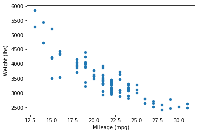

```python
auto.plot.scatter('Mileage (mpg)', 'Weight (lbs)')
```

1. Using the hist function in Matplotlib, create histograms for (non-normalized) Luggage (using 6 bins) and MPG (using 7 bins).

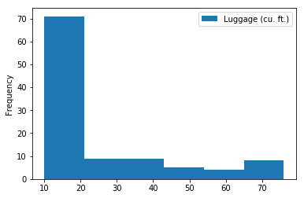

```python
auto[['Luggage (cu. ft.)']].plot(kind='hist', bins=6)
```

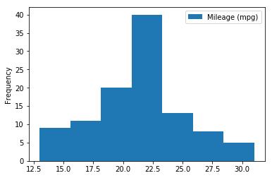

```python
auto[['Mileage (mpg)']].plot(kind='hist', bins=7)
```

1. Perform a cross-tabulation of the two "fuel type" variables versus the two "Drive type" variables. This requires the aggregation of the occurrences of each fuel type separately for each drive type (lookup the pandas crosstab function). Display it as as a 2 x 2 table with entries representing the counts. Then, create a bar chart graph to visualize the relationships between these sets of variables (comparing Regular and Premium customer across the two drive types). Your chart should contain appropriate labels for axes.

```python
autoCT = pd.crosstab(auto['Drive Type'],auto['Fuel Type'])
autoCT
```

| Fuel Type Drive Type | Premium | Regular |
| --- | --- | --- |
| Front | 11 | 70 |
| Rear | 8 | 17 |

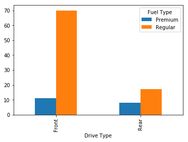

```python
autoCT.plot(kind='bar')
```

1. Create a new dataframe that only contains the data where fuel is “regular” AND MPG is over 21. Call it Auto_sub. Label each section using markup to state what you are doing and what you see.

```python
filterMPG = auto[auto['Mileage (mpg)']>21]
filterMPG.head()
```

|  | Name | Drive Type | Mileage (mpg) | Fuel Type | Capacity (gal) | Length (inches) | Wheel Base (inches) | Width (inches) | Turning Circle (feet) | Weight (lbs) | Door Top (inches) | Luggage (cu. ft.) | Front Shoulder (inches) | Front Leg Room (inches) | Front Head Room (inches) | Rear Shoulder (inches) | Rear Leg Room (inches) | Rear Head Room (inches) |
| --- | --- | --- | --- | --- | --- | --- | --- | --- | --- | --- | --- | --- | --- | --- | --- | --- | --- | --- |
| 0 | Acura TL | Front | 22 | Premium | 17.1 | 193 | 108 | 70 | 40 | 3460.0 | 50.0 | 14.0 | 56.0 | 40.5 | 2.5 | 55.0 | 27.0 | 2.0 |
| 1 | Infiniti I30 | Front | 22 | Premium | 18.5 | 194 | 108 | 70 | 40 | 3410.0 | 51.0 | 14.0 | 56.0 | 40.0 | 3.0 | 56.0 | 29.0 | 2.0 |
| 3 | Lexus ES300 | Front | 22 | Premium | 18.5 | 190 | 105 | 71 | 40 | 3390.0 | 50.0 | 13.0 | 55.0 | 41.0 | 2.0 | 53.5 | 27.5 | 1.5 |
| 8 | Volkswagen Passat | Front | 24 | Premium | 16.4 | 184 | 106 | 69 | 38 | 3175.0 | 51.0 | 15.0 | 55.5 | 42.5 | 6.5 | 53.5 | 29.0 | 3.0 |
| 9 | Audi A4 | Front | 22 | Premium | 15.9 | 178 | 103 | 68 | 36 | 3345.0 | 50.5 | 14.0 | 54.0 | 40.5 | 3.5 | 52.0 | 24.5 | 2.0 |

Here (above ^) I applied the 'first' filter that returns only the rows that contain cars with mileage better than 21 mpg.

```python
filterF = auto[auto['Fuel Type']=='Regular']
filterF.head()
```

|  | Name | Drive Type | Mileage (mpg) | Fuel Type | Capacity (gal) | Length (inches) | Wheel Base (inches) | Width (inches) | Turning Circle (feet) | Weight (lbs) | Door Top (inches) | Luggage (cu. ft.) | Front Shoulder (inches) | Front Leg Room (inches) | Front Head Room (inches) | Rear Shoulder (inches) | Rear Leg Room (inches) | Rear Head Room (inches) |
| --- | --- | --- | --- | --- | --- | --- | --- | --- | --- | --- | --- | --- | --- | --- | --- | --- | --- | --- |
| 19 | Acura Integra | Front | 31 | Regular | 13.2 | 172 | 101 | 67 | 39 | 2635.0 | 47.5 | 13.0 | 51.5 | 41.5 | 2.0 | 46.5 | 25.0 | 0.5 |
| 20 | Buick Century | Front | 22 | Regular | 17.5 | 195 | 109 | 73 | 40 | 3350.0 | 50.5 | 17.0 | 58.0 | 44.0 | 5.0 | 57.0 | 30.0 | 2.0 |
| 21 | Buick LeSabre | Front | 20 | Regular | 17.5 | 200 | 112 | 74 | 42 | 3640.0 | 51.0 | 18.0 | 59.5 | 40.5 | 5.0 | 58.0 | 27.5 | 4.5 |
| 22 | Buick Park Avenue | Front | 21 | Regular | 18.5 | 207 | 114 | 75 | 43 | 3880.0 | 51.0 | 19.0 | 59.5 | 42.5 | 6.0 | 58.5 | 31.5 | 3.0 |
| 23 | Buick Regal | Front | 21 | Regular | 17.5 | 196 | 109 | 73 | 40 | 3325.0 | 50.5 | 17.0 | 58.0 | 43.0 | 5.0 | 56.5 | 29.0 | 2.5 |

Here (above ^) I created the second filter that returns only cars that are for Fuel Type: Regular.

```python
Auto_sub = pd.merge(filterF, filterMPG, on='Name')
Auto_sub.head()
```

|  | Name | Drive Type_x | Mileage (mpg)_x | Fuel Type_x | Capacity (gal)_x | Length (inches)_x | Wheel Base (inches)_x | Width (inches)_x | Turning Circle (feet)_x | Weight (lbs)_x | ... | Turning Circle (feet)_y | Weight (lbs)_y | Door Top (inches)_y | Luggage (cu. ft.)_y | Front Shoulder (inches)_y | Front Leg Room (inches)_y | Front Head Room (inches)_y | Rear Shoulder (inches)_y | Rear Leg Room (inches)_y | Rear Head Room (inches)_y |
| --- | --- | --- | --- | --- | --- | --- | --- | --- | --- | --- | --- | --- | --- | --- | --- | --- | --- | --- | --- | --- | --- |
| 0 | Acura Integra | Front | 31 | Regular | 13.2 | 172 | 101 | 67 | 39 | 2635.0 | ... | 39 | 2635.0 | 47.5 | 13.0 | 51.5 | 41.5 | 2.0 | 46.5 | 25.0 | 0.5 |
| 1 | Buick Century | Front | 22 | Regular | 17.5 | 195 | 109 | 73 | 40 | 3350.0 | ... | 40 | 3350.0 | 50.5 | 17.0 | 58.0 | 44.0 | 5.0 | 57.0 | 30.0 | 2.0 |
| 2 | Chevrolet Cavalier | Front | 26 | Regular | 15.2 | 181 | 104 | 68 | 38 | 2795.0 | ... | 38 | 2795.0 | 50.5 | 14.0 | 54.5 | 41.5 | 4.5 | 53.5 | 28.0 | 2.0 |
| 3 | Chevrolet Lumina | Front | 22 | Regular | 16.6 | 201 | 108 | 73 | 44 | 3350.0 | ... | 44 | 3350.0 | 51.0 | 16.0 | 58.5 | 42.5 | 4.5 | 57.0 | 30.0 | 2.0 |
| 4 | Chevrolet Malibu | Front | 24 | Regular | 15.2 | 190 | 107 | 69 | 40 | 3075.0 | ... | 40 | 3075.0 | 50.5 | 17.0 | 55.0 | 43.0 | 4.5 | 54.0 | 30.5 | 2.0 |

5 rows × 35 columns